# Analysis of Lyme Disease Infection in the United States

As submitted by

Diwash Shrestha (12203784)

Daniel Eduardo Duran (12301739)

Email: diwash.shrestha@stud.th-deg.de Email: daniel.duran-vega@stud.th-deg.de

# **1. Introduction**

In December 1975 two researchers led a surveillance study to investigate the cause of a sudden outbreak of rheumatoid arthritis in and around a town named Lyme. The investigation which consisted of physical and blood examinations discovered that 25% of patients presented a rash on their skin, furthermore, this mysterious arthritis emerged with interesting geographical and temporal patterns, as most patients lived in proximity to towns. All this information led the authors to discover a tick-transmitted infection called Lyme disease (Daniel Jernigan, 2023; Elbaum-Garfinkle, 2011). In this study, we will use data from Project Tycho to gain a deeper understanding of the Lyme Disease. With the help of this dataset, we will review the temporal and geographical patterns of the disease and the implications of our findings for public health prevention and control efforts.

# **2. Problem definition**

In this work we will attempt to analyze the patterns of Lyme Disease. Specifically, we aim to analyze a data set from Project Tycho containing information on different diseases with their corresponding number of infections and death from 1888 to 2014. One challenge in this task is that the data is not evenly distributed among all diseases and may have certain limitations, such as underreporting bias or temporal bias due to the database not containing all reported years for Lyme Disease. Despite this, we expect this work to gain a deeper understanding of the factors that influence Lyme Disease and its behaviour in the United States.

# **3. Objectives**

- Identify the temporal and geographical patterns of Lyme disease in the United States
- Evaluate the implications of these patterns for public health prevention and control efforts.

# **4. Methods**

For the purposes of this analysis, we used the information provided by Project Tycho containing data on different diseases with their corresponding number of infections and death from 1888 to 2014. From the dataset, we selected Lyme Disease for this analysis as its different transmission vector from other diseases could expand our understanding of the patterns of tick-transmitted diseases. To obtain information on the temporal and geographical patterns of this disease we first identify the range in which Lyme Disease is found in the dataset and select the range of our assessment which for this work will include all available data from 2006 to 2014. Once our range was selected. We use advanced data visualization techniques such as the ones included in the libraries ggplot2, dygraphs, dygraphs, etc in R. With the help of this packages, we created bar charts, line charts and maps. Bar charts are a simple but effective way to visualize the distribution of data. We used bar charts to visualize the distribution of Lyme disease cases by state. Additionally, we used line plots as they are a good way to visualize the relationship between two variables such as cases and time or temperature, cases and time. These graphs will help us visualize the relationship between the number of Lyme disease cases and seasonality/temperature patterns. Finally, we will use Maps visualizations to observe the spatial distribution of data, which for this work will help us analyze the distribution of Lyme disease cases in the United States.

# **5. Analysis Protocol**

The analysis was divided into subsections. The working steps are introduced below.

Before to start the analysis the required libraries were loaded

## **5.1 Data Loading and Cleanup**

```r
# Import Data
tycho_db <- fread("data/ProjectTycho_Level2_v1.1.0_0/ProjectTycho_Level2_v1.1.0.csv")
```

```r
tycho_db %>% group_by(disease)%>%
  summarise(n = n())
```

| disease | n |
| --- | --- |
| ANTHRAX | 7051 |
| BABESIOSIS | 36 |
| BOTULISM | 10 |
| BRUCELLOSIS [UNDULANT FEVER] | 14970 |
| CHICKENPOX [VARICELLA] | 75198 |
| CHLAMYDIA | 16837 |
| CHOLERA | 125 |
| COCCIDIOIDOMYCOSIS | 1069 |
| CRYPTOSPORIDIOSIS | 7590 |
| DENGUE | 621 |

[output cut: 40 more lines]

**Table 1.** Disease summary of the dataset.

**Data loading**

Since we are analysing the lyme disease, we will filter data which contains the lyme disease.

```r
# Filter the Lyme disease data
lyme_db <-tycho_db %>% filter(disease == "LYME DISEASE")
```

- **Data Cleanup**

As the data is from USA only and we are focused on the lyme disease. We will remove the country, disease and url column and keep other relevant information.

```r
lyme_db <- lyme_db %>% select(-c('country','disease','url'))
```

- **Number of Cases and Deaths**

```r
lyme_db %>% group_by(event)%>%
  summarise(sum(number))
```

| event | sum(number) |
| --- | --- |
| CASES | 76952 |

**Table 2.** Total cases reported for Lyme Disease in the dataset.

In total there were 76952 cases and no death cases

# **6. Result**

In this section the overall trend of the cases occured in the USA was studied.

## **6.1 Yearly cases trend**

To initialize our analysis of the Lyme Disease cases occured in the Unites States, we first look into the amount of cases occurred in each year

```r
# break the epi_week column which has the year and week data combined
yr_wk_case_db <- lyme_db %>% group_by(epi_week)%>%
  summarise(cases = sum(number)) %>% separate(epi_week, into = c('year', 'week'), sep = -2, convert = TRUE)
yr_wk_case_db
```

| year | week | cases |
| --- | --- | --- |
| 2006 | 1 | 14 |
| 2006 | 2 | 17 |
| 2006 | 3 | 22 |
| 2006 | 4 | 22 |
| 2006 | 5 | 35 |
| 2006 | 6 | 33 |
| 2006 | 7 | 31 |
| 2006 | 8 | 23 |
| 2006 | 9 | 39 |
| 2006 | 10 | 144 |

[output cut: 437 more lines]

**Table 3.** Total cases per week of the year.

The resulted data frame has the data in the range of January 2006 to August 2014. As a consequence, We will only take data from 2006 to 2013 to have the uniformity for the yearly trend analysis.

```r
# group by yearly and find the cases on yearly basis
yr_case <- yr_wk_case_db%>%group_by(year)%>%
  summarise(cases = sum(cases)) %>%
  filter(year != 2014)
```

As we want to make the visualization uniform in our anlysis. A theme for the visualization is created for this analysis.

```r
# theme for visualization
my_theme <-   theme_minimal(base_size = 24)+theme(plot.title = element_text(hjust = 0.5,face = "bold"),
        plot.subtitle = element_text(hjust = 0.5,face = "italic"),legend.position="top")
```

- **Bar Plot**

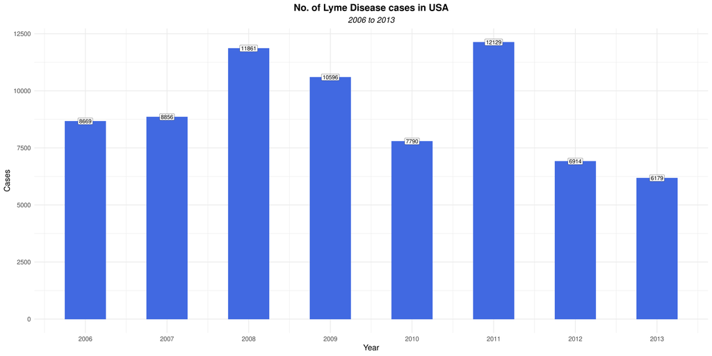

My Plot

```r
p <- ggplot(yr_case,aes(year,cases))+
  geom_col(width=0.5, fill="royalblue",color="royalblue")+
  geom_label(aes(label=cases),size=6)+
  scale_x_continuous(breaks=c(2006,2007,2008,2009,2010,2011,2012,2013,2014))+
  labs(title = "No. of Lyme Disease cases in USA",
       subtitle = "2006 to 2013",
       x = "Year",
       y = "Cases")+
  my_theme

p
```

**Fig 1.** Bar-plot of the total cases vs year.

- **Monthly Trends**

Given the high disparity in our data we decided to take the monthly pattern into account. To achieve this we are used the to_date columns to calculate the cases found till that date.

```r
year_month_cases <- lyme_db %>% group_by(to_date)%>%summarise(cases = sum(number))%>%separate(to_date, into = c('year_month', 'day'), sep = -3, convert = TRUE)%>%
  group_by(year_month)%>%
  summarise(cases = sum(cases))

year_month_cases$year_month <- zoo::as.yearmon(year_month_cases$year_month, format="%Y-%m")
```

- **Line Chart**

For the monthly trend we decided to use a line chart given that this graph is better suited to provide us with the trend analysis for the amount of monthly data given by the project.

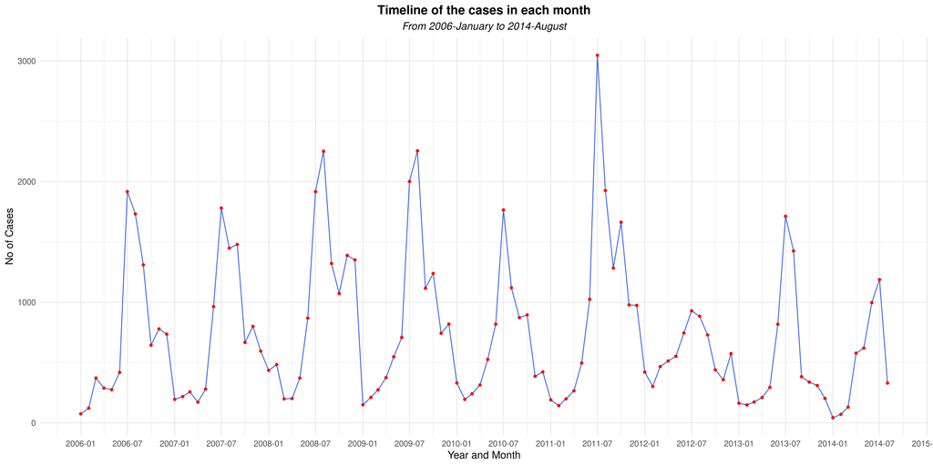

```r
p <- ggplot(year_month_cases, aes(as.Date(year_month), cases)) +
  geom_line(color="royalblue",size=1)+
    geom_point(color="red",size=3)+
  scale_x_date(date_breaks = "6 month",date_labels = "%Y-%m")+
  labs(title = "Timeline of the cases in each month",
       subtitle = "From 2006-January to 2014-August",
       x="Year and Month", y="No of Cases")+
  my_theme
p
```

**Fig 2.** Graph of Lyme Disease cases along the decided timeline.

The results of our line plot showed that Lyme Disease has a seasonality pattern, defined by a sharp increase of cases starting from March until August followed by an acute decline of cases from October to February. This pattern is consistently repeated every year.

## **6.2 Geographical analysis**

In this section the occurrence of lyme disease will be discussed based on the state and region of the United States.

- **Top 10 states with highest lyme disease cases**

```r
total_case_state <- lyme_db %>% group_by(state)%>%
  summarise(cases = sum(number))%>%arrange(-cases)
```

```r
# top 10 state with most cases
top_10_db <- lyme_db %>% group_by(state)%>%
  summarise(cases = sum(number))%>%arrange(-cases) %>%head(10)
top_10_db$state_name <-c("New York","Pennsylvania","Maryland","Virginia","Connecticut","New Jersey","Minnesota","Maine","Delware","Florida")
top_10_db
```

| state | cases | state_name |
| --- | --- | --- |
| NY | 28855 | New York |
| PA | 20121 | Pennsylvania |
| MD | 5211 | Maryland |
| VA | 3564 | Virginia |
| CT | 3393 | Connecticut |
| NJ | 3088 | New Jersey |
| MN | 2575 | Minnesota |
| ME | 2321 | Maine |
| DE | 1319 | Delware |
| FL | 1119 | Florida |

**Table 4.** Top 10 states from cases of Lyme Disease.

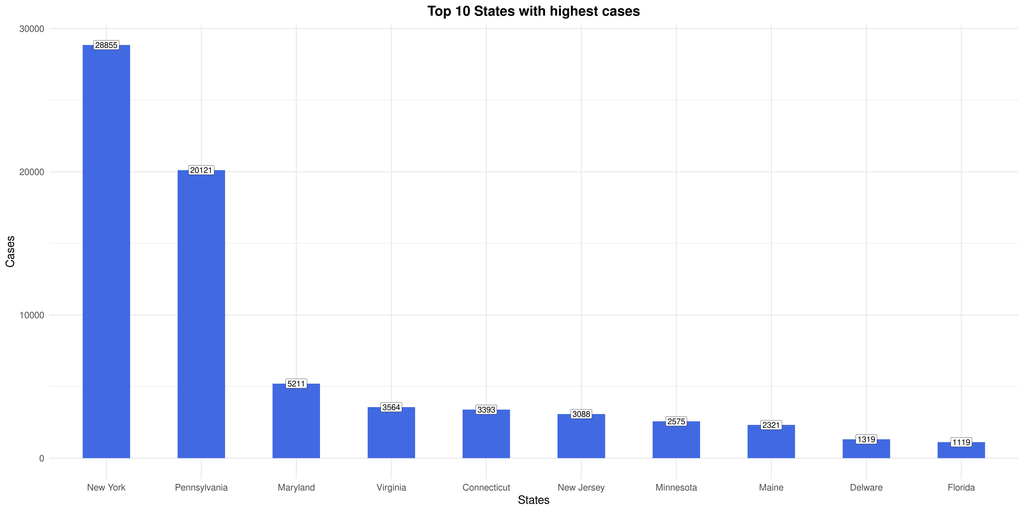

```r
# Top 10 state with cases
p <- ggplot(data = top_10_db)+
  geom_col(aes(reorder(state_name,-cases),cases),width=0.5, fill = "royalblue")+
  geom_label(aes(label=cases,reorder(state_name,-cases),cases),size=6)+
  labs(title = "Top 10 States with highest cases",
       x = "States",
       y = "Cases")+
  my_theme
p
```

**Fig 3.** Bar-plot of the total cases vs state.

- **Choropleth Map**

The Choropleth Map visualization technique make it easier to compare the data in a given map, as it colors the area with larger number with darker color and smaller one with lighter color. Hence, we used it to increase our understatement of geographical patterns in the USA.

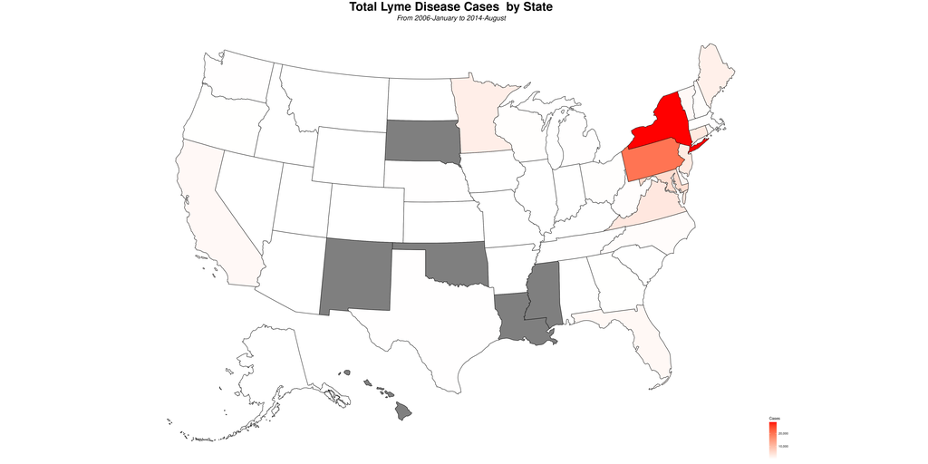

```r
plot_usmap(data = total_case_state, values = "cases", color = "black") +
  scale_fill_continuous(
    low = "white", high = "red", name = "Cases", label = scales::comma
  ) +labs(title = "Total Lyme Disease Cases  by State",
       subtitle = "From 2006-January to 2014-August",
       x="", y="")+
  theme(plot.title = element_text(hjust = 0.5,face = "bold",size = 28),
        plot.subtitle = element_text(hjust = 0.5,face = "italic",size = 16),legend.position = "right")
```

**Fig 4.** Choropleth Map of the united states for Lyme Disease cases.

Our spatial analysis shows that Lyme Disease is concentrated in the northeast of the united states, especially in the states of New York and Pennsylvania, which in conjunction contain the more than 50% of all the cases.

## **6.3 Trends in Northeast and Other State**

Looking into the choropleth map we wanted to look further as most of the cases seems to appears in northeastern state. Hence, we compared the northeast region with other remaining state.

```r
northeast_st <- c('CT','ME','MA','NH' ,'NJ','NY','PA','RI','VT')
```

```r
north_east_other_year_trend <- lyme_db %>% group_by(to_date,state)%>%summarise(cases = sum(number))%>%separate(to_date, into = c('year_month', 'day'), sep = -3, convert = TRUE)%>%
  mutate(region = case_when(
  state %in% northeast_st ~ "northeastern",
  .default = "other"
))%>%
  group_by(year_month,region)%>%
  summarise(cases = sum(cases))
north_east_other_year_trend$year_month <- zoo::as.yearmon(north_east_other_year_trend$year_month, format="%Y-%m")
```

```r
north_east_other_year_trend
```

| year_month | region | cases |
| --- | --- | --- |
| Jan 2006 | northeastern | 40 |
| Jan 2006 | other | 35 |
| Feb 2006 | northeastern | 78 |
| Feb 2006 | other | 44 |
| Mar 2006 | northeastern | 292 |
| Mar 2006 | other | 80 |
| Apr 2006 | northeastern | 260 |
| Apr 2006 | other | 29 |
| May 2006 | northeastern | 219 |
| May 2006 | other | 56 |

[output cut: 198 more lines]

**Table 5.** Northeastern cases against the rest of the states in the country.

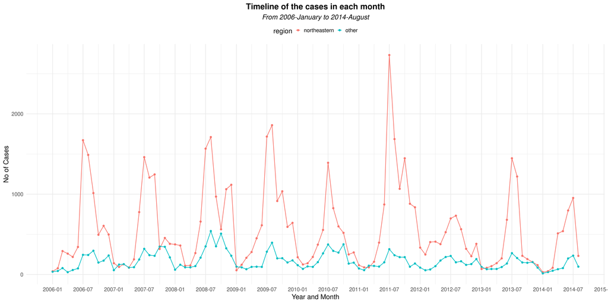

```r
p <- ggplot(north_east_other_year_trend, aes(as.Date(year_month), cases)) +
  geom_point(aes(color=region),size=3)+
  geom_line(aes(color=region),size=1)+
  scale_x_date(date_breaks = "6 month",date_labels = "%Y-%m")+
  labs(title = "Timeline of the cases in each month",
       subtitle = "From 2006-January to 2014-August",
       x="Year and Month", y="No of Cases")+
  my_theme
p
```

## **6.4 Temperature and Lyme Cases**

As we found the most of the cases are seen in the northeast state, you should remember we also notice the most effected states are New York and Pennsylvania. In this section we will focus on the temperature and cases of these states.

We extracted the data of the monthly average temperature of the Pennsylvania and new York to compare the cases and the temperature.

Temperature data was taken from (NOAA National Centers for Environmental Information, 2023).

```r
  # load the temperature data
temp_db <- fread("data/NY_PN_temp_data.csv")
temp_db$date <- zoo::as.yearmon(temp_db$date, format="%Y-%m")
```

```r
head(temp_db)
```

| date | state | value | anamoly |
| --- | --- | --- | --- |
| Jan 2006 | New York | 30.1 | 8.5 |
| Feb 2006 | New York | 24.7 | 1.2 |
| Mar 2006 | New York | 31.7 | 0.1 |
| Apr 2006 | New York | 45.7 | 1.8 |
| May 2006 | New York | 55.7 | -0.1 |
| Jun 2006 | New York | 64.4 | 0.0 |

**Table 6.** Head of the average temperature from New York and Pennsylvania states.

This data frame has the temperature in Fahrenheit of the New York and Pennsylvania state. In order to have a better representation we decided to convert the temperature in Fahrenheit to Celsius scale.

```r
temp_db <- temp_db %>%
  mutate(celcius_value = weathermetrics::fahrenheit.to.celsius(value))

temp_db
```

| date | state | value | anamoly | celcius_value |
| --- | --- | --- | --- | --- |
| Jan 2006 | New York | 30.1 | 8.5 | -1.06 |
| Feb 2006 | New York | 24.7 | 1.2 | -4.06 |
| Mar 2006 | New York | 31.7 | 0.1 | -0.17 |
| Apr 2006 | New York | 45.7 | 1.8 | 7.61 |
| May 2006 | New York | 55.7 | -0.1 | 13.17 |
| Jun 2006 | New York | 64.4 | 0.0 | 18.00 |
| Jul 2006 | New York | 71.0 | 2.0 | 21.67 |
| Aug 2006 | New York | 66.8 | -0.6 | 19.33 |
| Sep 2006 | New York | 58.1 | -2.3 | 14.50 |
| Oct 2006 | New York | 46.6 | -2.2 | 8.11 |

[output cut: 206 more lines]

**Table 7.** Data frame of the average temperature from New York and Pennsylvania states in Celsius.

```r
# convert the fahrenheit anamoly  to celcius anamoly

temp_db <- temp_db %>%
  mutate(celcius_anamoly = (anamoly) *(5/9))
```

```r
# extract the total cases of the New York and Pennsylvania on monthly basis from 2006 to 2014
ny_pa_cases <- lyme_db %>% group_by(to_date,state)%>%summarise(cases = sum(number))%>%separate(to_date, into = c('year_month', 'day'), sep = -3, convert = TRUE)%>%
  filter(state %in% c('NY','PA'))%>%
  group_by(year_month, state)%>%
  summarise(cases = sum(cases))
ny_pa_cases$year_month <- zoo::as.yearmon(ny_pa_cases$year_month, format="%Y-%m")
ny_pa_cases
```

| year_month | state | cases |
| --- | --- | --- |
| Jan 2006 | NY | 16 |
| Jan 2006 | PA | 22 |
| Feb 2006 | NY | 55 |
| Feb 2006 | PA | 15 |
| Mar 2006 | NY | 259 |
| Mar 2006 | PA | 17 |
| Apr 2006 | NY | 240 |
| Apr 2006 | PA | 14 |
| May 2006 | NY | 159 |
| May 2006 | PA | 35 |

[output cut: 194 more lines]

```r
# change the name of the year_month column to date and change the value in state column to full name
# use the two columns to combine the ny_pa_cases and temp_db dataframe

ny_pa_cases <- ny_pa_cases %>%
  rename(date = year_month)%>%
  mutate(state = case_when(state == 'NY' ~'New York',
                           .default = 'Pennsylvania'))

ny_pa_cases
```

| date | state | cases |
| --- | --- | --- |
| Jan 2006 | New York | 16 |
| Jan 2006 | Pennsylvania | 22 |
| Feb 2006 | New York | 55 |
| Feb 2006 | Pennsylvania | 15 |
| Mar 2006 | New York | 259 |
| Mar 2006 | Pennsylvania | 17 |
| Apr 2006 | New York | 240 |
| Apr 2006 | Pennsylvania | 14 |
| May 2006 | New York | 159 |
| May 2006 | Pennsylvania | 35 |

[output cut: 194 more lines]

**Table 8.** Cases of New York state and Pennsilvanya sate per month and year.

```r
# Join the two dataframe using the state and date as ID
ny_pa_temp_case_db <- inner_join(ny_pa_cases, temp_db,by = c( "date","state"))
ny_pa_temp_case_db
```

| date | state | cases | value | anamoly | celcius_value | celcius_anamoly |
| --- | --- | --- | --- | --- | --- | --- |
| Jan 2006 | New York | 16 | 30.1 | 8.5 | -1.06 | 4.72222222 |
| Jan 2006 | Pennsylvania | 22 | 35.2 | 8.6 | 1.78 | 4.77777778 |
| Feb 2006 | New York | 55 | 24.7 | 1.2 | -4.06 | 0.66666667 |
| Feb 2006 | Pennsylvania | 15 | 29.8 | 0.9 | -1.22 | 0.50000000 |
| Mar 2006 | New York | 259 | 31.7 | 0.1 | -0.17 | 0.05555556 |
| Mar 2006 | Pennsylvania | 17 | 37.0 | 0.2 | 2.78 | 0.11111111 |
| Apr 2006 | New York | 240 | 45.7 | 1.8 | 7.61 | 1.00000000 |
| Apr 2006 | Pennsylvania | 14 | 50.5 | 2.1 | 10.28 | 1.16666667 |
| May 2006 | New York | 159 | 55.7 | -0.1 | 13.17 | -0.05555556 |
| May 2006 | Pennsylvania | 35 | 57.3 | -1.3 | 14.06 | -0.72222222 |

[output cut: 194 more lines]

**Table 9.** Joint data frame of cases of New York state and Pennsilvanya sate per month and year with temperature.

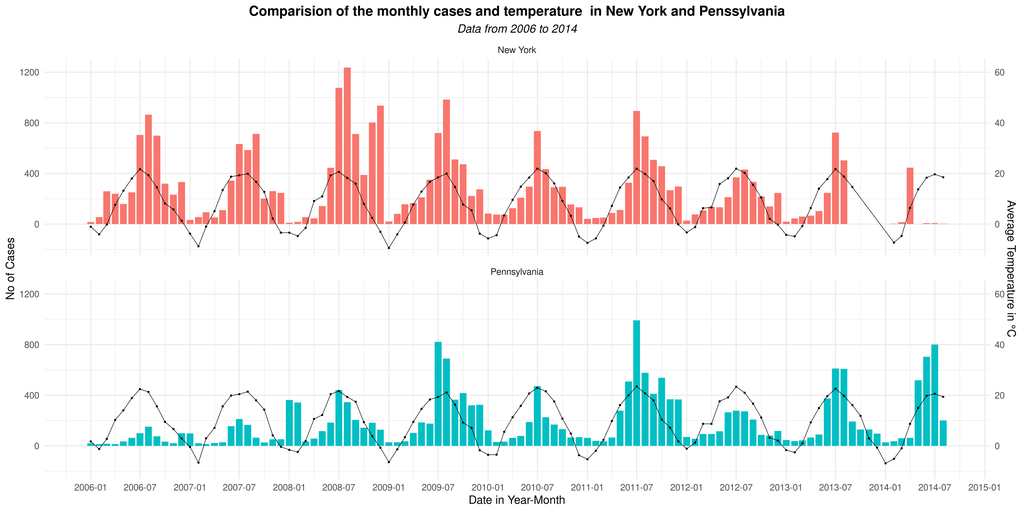

```r
coeff = 20
p <- ggplot(ny_pa_temp_case_db, aes(x = as.Date(date))) +
  geom_col(aes(y = cases,fill=state))+
  geom_point(aes(y = (celcius_value*coeff)))+
  geom_line(aes(y = (celcius_value*coeff)))+
  scale_x_date(date_breaks = "6 month",date_labels = "%Y-%m")+
  facet_wrap(~state,ncol=1)+
  scale_y_continuous(

    # Features of the first axis
    name = "No of Cases",

    # Add a second axis and specify its features
    sec.axis = sec_axis(~./coeff, name="Average Temperature in °C")
  )+
  labs(title = "Comparision of the monthly cases and temperature  in New York and Penssylvania",
       subtitle = "Data from 2006 to 2014",x="Date in Year-Month"
       )+
  my_theme+ theme(legend.position="")
p
```

**Fig 6.** Temperature + total cases vs time